# Fraudulent job postings

## Simple neural network (using `Keras`)

- We first convert the tfidf values into a recognisable form that Keras can use.
- `GaussianNoise` layers and `Dropout` layers are added to prevent the model from overfitting
- F2 score of the predictions is tracked. The model ends training early if the next three F2 scores are lower.
- The predictions from the epoch with the highest F2 score is then used.

```python
def convert_sparse_matrix_to_sparse_tensor(X):
    coo = X.tocoo()
    indices = np.mat([coo.row, coo.col]).transpose()
    return tf.sparse.reorder(tf.sparse.SparseTensor(indices, coo.data, coo.shape))

X2_train = convert_sparse_matrix_to_sparse_tensor(X_train_vectorized)
X2_test = convert_sparse_matrix_to_sparse_tensor(X_test_vectorized)
```

```python
model = tf.keras.Sequential([
    tf.keras.layers.Dense(1, input_shape=X2_train.shape, activation='relu'),
    tf.keras.layers.GaussianNoise(0.2),
    tf.keras.layers.Dense(5, activation='relu'),
    tf.keras.layers.Dropout(0.3),
    tf.keras.layers.Dense(1, activation='sigmoid')
])
model.compile(loss='binary_crossentropy', optimizer='adamax', metrics=['accuracy', 'Recall'])
model.summary()

# Uncomment below if running again
if 'test_ANN_F2' in locals():
    del train_ANN_F2
    del test_ANN_F2
```

```
Model: "sequential_3"
_________________________________________________________________
Layer (type)                 Output Shape              Param #
=================================================================
dense_9 (Dense)              (None, 22933, 1)          20001
_________________________________________________________________
gaussian_noise_3 (GaussianNo (None, 22933, 1)          0
_________________________________________________________________
dense_10 (Dense)             (None, 22933, 5)          10
_________________________________________________________________
dropout_3 (Dropout)          (None, 22933, 5)          0
_________________________________________________________________
dense_11 (Dense)             (None, 22933, 1)          6
=================================================================
Total params: 20,017
Trainable params: 20,017
Non-trainable params: 0
_________________________________________________________________
```

The callbacks ideally should be monitoring the metrics on the validation dataset. But I couldn't get it to work, so i designed my own checking system.

```
Epoch 1 	- prev F2 scores: train = 0.0, test = 0.0
Epoch 2 	- prev F2 scores: train = 0.9544, test = 0.7282
Epoch 3 	- prev F2 scores: train = 0.9583, test = 0.7819
Epoch 4 	- prev F2 scores: train = 0.9632, test = 0.8047
Epoch 5 	- prev F2 scores: train = 0.9721, test = 0.8248
Epoch 6 	- prev F2 scores: train = 0.977, test = 0.8341
Epoch 7 	- prev F2 scores: train = 0.9813, test = 0.8421
Epoch 8 	- prev F2 scores: train = 0.9831, test = 0.8398
Epoch 9 	- prev F2 scores: train = 0.9885, test = 0.843
Epoch 10 	- prev F2 scores: train = 0.9896, test = 0.8423
Epoch 11 	- prev F2 scores: train = 0.9928, test = 0.8431
Epoch 12 	- prev F2 scores: train = 0.9939, test = 0.8448
Epoch 13 	- prev F2 scores: train = 0.9947, test = 0.8431
Epoch 14 	- prev F2 scores: train = 0.9955, test = 0.8448
Epoch 15 	- prev F2 scores: train = 0.9959, test = 0.8473
Epoch 16 	- prev F2 scores: train = 0.9964, test = 0.844
Epoch 17 	- prev F2 scores: train = 0.9965, test = 0.849
Epoch 18 	- prev F2 scores: train = 0.9969, test = 0.8547
Epoch 19 	- prev F2 scores: train = 0.997, test = 0.8475
Epoch 20 	- prev F2 scores: train = 0.9972, test = 0.8532

>> F2 Score has decreased, so stopping training and using previous predictions.

Classification Accuracy	: 0.9832214765100671
Matthew's Corr. Coeff.	: 0.8149338844925291
ROC AUC Score		: 0.9331185902271493
F1 Score		: 0.821852731591449
F2 Score		: 0.8547430830039526

Confusion Matrix:
```

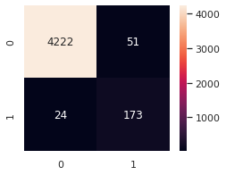

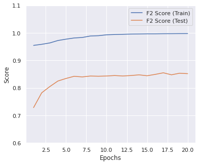

```python
# callback = keras.callbacks.EarlyStopping(monitor='val_accuracy', patience=2)

# Initialise values if not created yet
if 'test_ANN_F2' not in locals():
    train_ANN_F2 = [0.0]
    test_ANN_F2 = [0.0]
    predictions = np.zeros(y_test.shape)
    prev_preds = np.zeros(y_test.shape)
    prev_preds2 = np.zeros(y_test.shape)

# Custom loop to track F2 score for each epoch and end early when the next 3 F2 scores are lower
for i in range(len(test_ANN_F2)-1, 30):
    print(f'Epoch {i+1} \t- prev F2 scores: train = {round(train_ANN_F2[i], 4)}, test = {round(test_ANN_F2[i], 4)}')
    history = model.fit(X2_train, y_train, epochs=1)#, batch_size=32)
    predictions = np.squeeze(model.predict(X2_test) > 0.5).astype("int32")
    train_ANN_F2.append(fbeta_score(y_train, np.squeeze(model.predict(X2_train) > 0.5).astype("int32"), 2))
    test_ANN_F2.append(fbeta_score(y_test, predictions, 2))

    if i >= 3: # Minimum 3 epochs
        if ((test_ANN_F2[i+1] < test_ANN_F2[i-2]) and (test_ANN_F2[i] < test_ANN_F2[i-2])
        and (test_ANN_F2[i-1] < test_ANN_F2[i-2])): # Simulate patience of 3
            print('\n>> F2 Score has decreased, so stopping training and using previous predictions.\n')
            predictions = prev_preds3
            break
        prev_preds3 = prev_preds2
        prev_preds2 = prev_preds
        prev_preds = predictions

# Print some metric scores
print('Classification Accuracy\t:', accuracy_score(y_test, predictions))
print('Matthew\'s Corr. Coeff.\t:', matthews_corrcoef(y_test, predictions))
print('ROC AUC Score\t\t:', roc_auc_score(y_test, predictions))
print('F1 Score\t\t:', f1_score(y_test, predictions))
print('F2 Score\t\t:', fbeta_score(y_test, predictions, 2))
print('\nConfusion Matrix:')
plt.subplots(1, 1, figsize=(4, 3))
sb.heatmap(confusion_matrix(y_test, predictions), annot=True, square=True, fmt='d');

roc_dict['Simple Neural Network'] = roc_auc_score(y_test, predictions)
f2_dict['Simple Neural Network'] = fbeta_score(y_test, predictions, 2)

plt.subplots(1, 1, figsize=(6, 5))
plt.plot(range(1, len(train_ANN_F2)), train_ANN_F2[1:])
plt.plot(range(1, len(test_ANN_F2)), test_ANN_F2[1:])
plt.xlabel('Epochs')
plt.ylabel('Score')
plt.ylim(0.6, 1.1)
plt.legend(['F2 Score (Train)', 'F2 Score (Test)'])
plt.show()
```

As seen from the graph above, the model begins to overfit eventhough we drop some connections and introduced some Gaussian Noise. During testing with other layers, the model's best accuracy hovers near the 0.83 range.

## Conclusion: Modelling

- The Logistic Regression ^ classifier is the best at detecting fraudulent job posting with the highest F2 score.
- Fixing the class imbalance is important.
- Looking at the important features identified by the classifiers, it is confirmed that our hypothesis that `company_profile_specified` and `company_logo` are good indicators of whether a job is fraudulent.
- The simple neural network does not improve our metric scores from Logistic Regression, even after overfitting mitigations. This may be because we do not know how to define our layers in the neural network, so it is not recommended at this stage.

> **^ Logistic Regression: How it Works**
> - Logistic Regression can be used as a classification model
> - Performs linear regression first, output is $z$. Then passes through a sigmoid function, $y=\sigma(z)$, where $\sigma(z)=\frac{1}{1+e^{-z}}$.
> - Distinct boundary at $y=0.5$ (above is 1, below is 0)

[figure not shown]

> - Is a form of neural network, but scikit-learn takes care of the technical implementation
> - We also use the default L2 regularization, to prevent the model from overfitting to the train data.

[figure not shown]

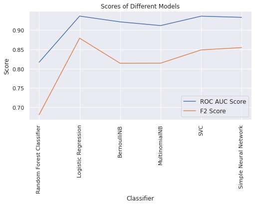

```python
plt.figure(figsize=(8, 4))
plt.plot(list(roc_dict.values()));
plt.plot(list(f2_dict.values()));
plt.xticks(ticks=range(0, len(roc_dict)), labels=roc_dict.keys(), rotation=90);
plt.title('Scores of Different Models');
plt.xlabel('Classifier');
plt.ylabel('Score');
plt.legend(['ROC AUC Score', 'F2 Score'], fontsize='medium');
```

# Our takeaways

For this project, our objectives were as below and we have determined the answers for them.

[figure not shown]

- Find associated features with a fraudulent and non-fraudulent posting.
  - *See below* after final code block

We now use all the features (not capped to 20000 maximum only) so that we can identify the features that are related to fraudulent and non-fraudulent job postings.

```
Vectorising your data ...
• Number of features: 837531
• Vector transformation done!
```

```
Classification Accuracy	: 0.9892617449664429
Matthew's Corr. Coeff.	: 0.8687279308640062
ROC AUC Score		: 0.9193305622246166
F1 Score		: 0.8736842105263157
F2 Score		: 0.854788877445932

Confusion Matrix:
```

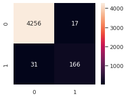

```python
print('Vectorising your data ...  ')
X_train, X_test, y_train, y_test = train_test_split(df_end.text, df_end.fraud, random_state=0)

vect = TfidfVectorizer(min_df=1, ngram_range=(1, 2)).fit(X_train)
print(f'• Number of features: {len(vect.get_feature_names())}')
X_train_vectorized = vect.transform(X_train)
X_test_vectorized = vect.transform(X_test)
print('• Vector transformation done!')

oversample = SMOTE(sampling_strategy=0.8, random_state=0)
X_train_vectorized, y_train = oversample.fit_resample(X_train_vectorized, y_train)

trained_model5, _, _ = skmodel(LogisticRegression(C=12, solver='liblinear'))
```

These are the top countries which send out fraudulent postings, as identified by our model.

```python
# Top countries which sends out fraudulent postings

model5_df = pd.DataFrame()
model5_df['weights'] = pd.DataFrame(trained_model5.coef_).T[0]
model5_df['features'] = vect.get_feature_names()
model5_df = model5_df.sort_values(by='weights', ascending=False)
model5_df['country'] = model5_df['features'].str.extract(r'country_(?P<country>[a-z]+)')
fraud_countries = model5_df['country'].dropna().drop_duplicates(keep='first')
fraud_countries = fraud_countries[fraud_countries.map(len) <= 2].str.upper().reset_index(drop=True)
fraud_countries.tolist()[:10]
```

```
['US', 'AU', 'PL', 'MY', 'PK', 'ID', 'BH', 'CA', 'ES', 'GB']
```

The features highlighted in green below are associated with the fraudulent postings while the features highlighted in red are associated with non-fradulent postings.

```python
eli5.explain_weights(trained_model5, feature_names=vect.get_feature_names(), top=(20, 20))
```

**y=1** top features

| Weight<sup>?</sup> | Feature |
| --- | --- |
| +11.483 | company_logo_no company_profile_no |
| +9.350 | company_logo_no |
| +8.943 | company_profile_no |
| +8.530 | company_profile_no has_questions_no |
| +6.954 | data entry |
| +6.883 | city_unspecified company_logo_no |
| +6.336 | accion |
| +5.846 | earn |
| +5.609 | entry |
| +5.569 | using link |
| +5.376 | subsea |
| +5.264 | assistant |
| +5.241 | apply using |
| +5.182 | money |
| +4.909 | administrative |
| +4.810 | engineering |
| +4.527 | industry_accounting |
| +4.467 | perioperative |
| +4.285 | link |
| +4.239 | aker |
| *… 53808 more positive …* |  |
| *… 783684 more negative …* |  |
| -2.656 | software |
| -2.682 | search |
| -2.806 | recruitment |
| -2.836 | experience |
| -2.845 | company_profile_yes has_questions_no |
| -2.878 | employment |
| -3.015 | web |
| -3.061 | company_logo_yes company_profile_yes |
| -3.082 | marketing |
| -3.181 | english |
| -3.232 | team |
| -3.260 | clients |
| -3.269 | company_profile_yes |
| -3.323 | client |
| -3.363 | digital |
| -3.365 | website |
| -3.475 | growing |
| -3.493 | <BIAS> |
| -3.688 | company_logo_yes |
| -3.795 | companies |